# Course Project - MATH2319 Machine Learning | Sem 1, 2020

## Honour Code

We solemnly swear that we have not discussed our assignment solutions with anyone in any way and the solutions we are submitting are our own personal work.

Full Name: Ankit Munot (s3764950), Akshay Sunil Salunke (s3730440) | Group 12

- Objective
- Source and description of dataset
  - Dataset
  - Target feature
  - Descriptive features
- Data preprocessing
  - Preliminaries
  - Data cleaning and transformation
  - Summary of features
- Data Exploration and Visualisation
  - Univariate visualizations
  - Bivariate visualizations
  - Multivariate visualizations
- Methodology
  - Feature selection
  - Model fitting
    - K-Nearest Neighbor (KNN)
    - Decision Tree Classifier
    - Random Forest Classifier
    - Support Vector Machine
  - Performance Comparison
- Model Evaluation
- Summary and Conclusion
- References

# Objective

The objective of this project is to predict mobile phone price range, based on various features a phone has. We predict price for a phone as a price-bucket rather than as a continuos feature, hence the problem at hand is multinomial classification problem. We have performed following steps in this project, data visualization, data preprocessing, feature selection (using f-score and random forest), model evaluation (4 models).

# Source and description of dataset

## Dataset

The dataset for this project was sourced from [kaggle.com](https://www.kaggle.com/iabhishekofficial/mobile-price-classification). A copy of dataset is included in `/data` folder, as accessed on `26 May 2020`. The dataset originally has 2,000 rows, but we have randomly sampled 1200 rows so that our laptops could cope up. The dataset has 20 features(excluding target), some of which are binary (eg. `wifi`, `bluetooth`, etc.) and denote if a phone has that particular feature, whereas some are continuos features (eg. `batter_power`, `ram`, etc.)

## Target feature

The target feature for this dataset is `price_range`, which has `0,1,2,3` as possible values, which represents phone price category corresponding to `low, mid, high, v.high`

## Descriptive features

The dataset has followinf descriptive features:

- `battery_power`: Total energy a battery can store in one time measured in *mAh.*
- `bluetooth`: Has bluetooth or not.
- `clock_speed`: Speed at which microprocessor executes instructions in *GHz*.
- `dual_sim`: Has dual sim support or not.
- `front_cam_mp`: Front Camera mega pixels.
- `four_g`: Has 4G or not.
- `int_memory`: Internal Memory in *Gigabytes*.
- `n_cores`: Number of cores of processor.
- `back_cam_mp`: Primary Camera in *Megapixels*.
- `px_height`: Pixel Resolution Height in *pixels*.
- `px_width`: Pixel Resolution Width in *pixels*.
- `ram`: Random Access Memory in *Megabytes*.
- `sc_h`: Screen Height of mobile in *cm*.
- `sc_w`: Screen Width of mobile in *cm*.
- `talk_time`: longest time that a single battery charge will last when you are on a call, in *Hours*.
- `three_g`: Has 3G or not.
- `touch_screen`: Has touch screen or not.
- `wifi`: Has wifi or not.
- `screen_size`: Screen size diagonally in *inches*.

Some of the features have been transformed into new features, for example, `sc_h` and `sc_w` have been transformed into `screen_size`, which is screen size measured diagonally in inches, which is the industry standard for measuring phone screen sizes.

# Data preprocessing

## Preliminaries

We import relevant datascience libraries, which we could think off top of our heads. Also, ignore the warning(because they're annoying).

```python
import pandas as pd
import matplotlib.pyplot as plt
import numpy as np
from sklearn import preprocessing
import sklearn
import warnings
import seaborn as sns
warnings.filterwarnings('ignore')
%matplotlib inline
```

We now read the data in an pandas dataframe. We randomly sample 1200 rows, with a fixed `random_state` so that results are reproducible.

```python
df = pd.read_csv("s3730440_data.csv")
df = df.sample(1200, random_state=786)
```

Here's how the original dataset looks like:

```python
df.head()
```

|  | battery_power | blue | clock_speed | dual_sim | fc | four_g | int_memory | m_dep | mobile_wt | n_cores | ... | px_height | px_width | ram | sc_h | sc_w | talk_time | three_g | touch_screen | wifi | price_range |
| --- | --- | --- | --- | --- | --- | --- | --- | --- | --- | --- | --- | --- | --- | --- | --- | --- | --- | --- | --- | --- | --- |
| 80 | 1589 | 1 | 0.6 | 1 | 0 | 1 | 58 | 0.9 | 85 | 7 | ... | 319 | 1206 | 3464 | 19 | 10 | 6 | 1 | 1 | 1 | 3 |
| 880 | 1554 | 0 | 2.7 | 1 | 3 | 1 | 47 | 0.7 | 185 | 5 | ... | 319 | 1367 | 509 | 12 | 3 | 19 | 1 | 0 | 0 | 0 |
| 466 | 1653 | 0 | 0.5 | 1 | 2 | 1 | 37 | 0.9 | 176 | 4 | ... | 447 | 1785 | 3955 | 19 | 4 | 18 | 1 | 1 | 1 | 3 |
| 1781 | 1876 | 0 | 1.3 | 1 | 9 | 1 | 64 | 1.0 | 98 | 3 | ... | 600 | 1211 | 3132 | 17 | 0 | 2 | 1 | 1 | 1 | 3 |
| 898 | 1372 | 1 | 2.7 | 0 | 7 | 0 | 34 | 0.4 | 193 | 4 | ... | 687 | 937 | 725 | 11 | 3 | 20 | 1 | 0 | 0 | 0 |

5 rows × 21 columns

And here is it's shape: (rows, columns)

```python
df.shape
```

```
(1200, 21)
```

## Data cleaning and transformation

In this section we remove the irrelevant features, transform existing features into new, etc.

We now check for any null values right off the bat, in all `df`.

```python
df.isnull().any()
```

```
battery_power    False
blue             False
clock_speed      False
dual_sim         False
fc               False
four_g           False
int_memory       False
m_dep            False
mobile_wt        False
n_cores          False
pc               False
px_height        False
px_width         False
ram              False
sc_h             False
sc_w             False
talk_time        False
three_g          False
touch_screen     False
wifi             False
price_range      False
dtype: bool
```

But isnull() only detects those values which are `NaN` or `None`. This is not enough and we still need to check the `df` for missing values in other formats, for example `?` or `0`.

We first rename the columns to more readable and understandable names.

```python
df = df.rename(columns={'blue':'bluetooth', 'fc':'front_cam_mp', 'sc_h':'screen_ht', 'sc_w':'screen_wt', 'pc':'back_cam_mp'})
```

Then, we drop the columns like `mobile_wt` and `m_dep` which we think are not actual deciding factors for a phone price, but more of a byproduct after the phone has been already manufactured. We also dropped `px_height` and `px_width` since it played very little to no role as a deciding factor for price of a phone, for the general consumer, since most of the consumers focus on the physical screen size rather than how many pixels a display has.

```python
df = df.drop(columns=['m_dep', 'mobile_wt', 'px_height', 'px_width'])
```

Now we perform binning of continuos feature `clock_speed`, into 3-bins namely, `low, mid, high` which correspond to following buckets `0-1, 1-2, 2-3`, in *Ghz*.

```python
df['clock_speed'] = pd.cut(df['clock_speed'], bins=[0, 1, 2, 3], labels = ['low', 'mid', 'high'])
level_map = {'low':0, 'mid':1, 'high':2}
df['clock_speed'] = df['clock_speed'].replace(level_map)
df.head()
```

|  | battery_power | bluetooth | clock_speed | dual_sim | front_cam_mp | four_g | int_memory | n_cores | back_cam_mp | ram | screen_ht | screen_wt | talk_time | three_g | touch_screen | wifi | price_range |
| --- | --- | --- | --- | --- | --- | --- | --- | --- | --- | --- | --- | --- | --- | --- | --- | --- | --- |
| 80 | 1589 | 1 | 0 | 1 | 0 | 1 | 58 | 7 | 7 | 3464 | 19 | 10 | 6 | 1 | 1 | 1 | 3 |
| 880 | 1554 | 0 | 2 | 1 | 3 | 1 | 47 | 5 | 12 | 509 | 12 | 3 | 19 | 1 | 0 | 0 | 0 |
| 466 | 1653 | 0 | 0 | 1 | 2 | 1 | 37 | 4 | 6 | 3955 | 19 | 4 | 18 | 1 | 1 | 1 | 3 |
| 1781 | 1876 | 0 | 1 | 1 | 9 | 1 | 64 | 3 | 19 | 3132 | 17 | 0 | 2 | 1 | 1 | 1 | 3 |
| 898 | 1372 | 1 | 2 | 0 | 7 | 0 | 34 | 4 | 17 | 725 | 11 | 3 | 20 | 1 | 0 | 0 | 0 |

We also transform the features `screen_wt` and `screen_ht` which are in *cm*, to new feature `screen_size` which is the diagonal screen size in *inches*, which is the industry standard for measuring screen sizes of phones.

```python
df[['screen_ht', 'screen_wt']].describe()

# Convert column datatypes to float.
df['screen_ht'] = df['screen_ht'].astype(float)
df['screen_wt'] = df['screen_wt'].astype(float)
```

We first handle the missing values in `screen_wt`. For this, we find the height for missing width, calculate mean width for that height in whole df, then append this mean to missijg value.

```python
# Create a temp list of all screen heights whose screen width is 0.
x = df[df['screen_wt']==0]['screen_ht'].value_counts().index.tolist()

# Create a list of all screen heights whose screen width is 0.
arr = []
for d in df.loc[df['screen_wt']==0]['screen_ht']:
    arr.append(d)

# Calculate mean width for a specific screen height.
# We create set out of screen heights list so that width is calculated only for unique screen heights.
# mean_width stores all unique screen heights, and their mean width.
mean_width = {}
for d in set(arr):
    total = 0
    n = 0
    for width in df.loc[df['screen_ht'] == d]['screen_wt']:
        if width == 0:
            pass
        total += width
        n += 1
        mean = round(total/n, 2)
    print("Mean width for height", d, "=", mean)
    mean_width[d] = mean

# Append all missing screen widths with the mean screen width for that specific height.
for z in x:
    df['screen_wt'] = np.where(((df['screen_wt']==0.0) & (df['screen_ht']==z)), mean_width.get(z), df['screen_wt'])
```

```
Mean width for height 5.0 = 2.24
Mean width for height 6.0 = 2.33
Mean width for height 7.0 = 3.36
Mean width for height 8.0 = 3.94
Mean width for height 9.0 = 3.77
Mean width for height 10.0 = 4.04
Mean width for height 11.0 = 5.49
Mean width for height 12.0 = 5.96
Mean width for height 13.0 = 6.08
Mean width for height 14.0 = 6.66
Mean width for height 15.0 = 7.21
Mean width for height 16.0 = 7.19
Mean width for height 17.0 = 8.11
Mean width for height 18.0 = 7.57
Mean width for height 19.0 = 9.05
```

```python
df.head()
```

|  | battery_power | bluetooth | clock_speed | dual_sim | front_cam_mp | four_g | int_memory | n_cores | back_cam_mp | ram | screen_ht | screen_wt | talk_time | three_g | touch_screen | wifi | price_range |
| --- | --- | --- | --- | --- | --- | --- | --- | --- | --- | --- | --- | --- | --- | --- | --- | --- | --- |
| 80 | 1589 | 1 | 0 | 1 | 0 | 1 | 58 | 7 | 7 | 3464 | 19.0 | 10.00 | 6 | 1 | 1 | 1 | 3 |
| 880 | 1554 | 0 | 2 | 1 | 3 | 1 | 47 | 5 | 12 | 509 | 12.0 | 3.00 | 19 | 1 | 0 | 0 | 0 |
| 466 | 1653 | 0 | 0 | 1 | 2 | 1 | 37 | 4 | 6 | 3955 | 19.0 | 4.00 | 18 | 1 | 1 | 1 | 3 |
| 1781 | 1876 | 0 | 1 | 1 | 9 | 1 | 64 | 3 | 19 | 3132 | 17.0 | 8.11 | 2 | 1 | 1 | 1 | 3 |
| 898 | 1372 | 1 | 2 | 0 | 7 | 0 | 34 | 4 | 17 | 725 | 11.0 | 3.00 | 20 | 1 | 0 | 0 | 0 |

We now transform the `screen_height` and `screen_width` features to `screen_size` feature. Using the formula for diagonal of a rectangle = $\sqrt{width^2 + heigth^2}$. Then we convert to *inches* by dividing with 2.54.

```python
df['screen_size'] = df['screen_ht']**2 + df['screen_wt']**2
df['screen_size'] = np.sqrt(df['screen_size'])
df['screen_size'] = df['screen_size']/2.54
df['screen_size'] = df['screen_size'].round(2)
df.drop(columns=['screen_ht', 'screen_wt'], inplace=True)

p = pd.DataFrame(df['price_range'])
df.drop(columns=['price_range'], inplace=True)
df = df.join(p)
```

We also, seperate out the categorical features, continuos features and the target feature in seperate variables.

```python
categorical_features = ['bluetooth', 'dual_sim', 'four_g', 'three_g', 'touch_screen', 'wifi']
continuous_features = ['battery_power', 'front_cam_mp', 'int_memory', 'n_cores', 'back_cam_mp', 'ram', 'clock_speed', 'talk_time']
TARGET = ['price_range']
```

## Summary of features

We describe the continuos features, to understand the dataset and draw some insights.

```python
df[continuous_features].describe(include='all')
```

|  | battery_power | front_cam_mp | int_memory | n_cores | back_cam_mp | ram | clock_speed | talk_time |
| --- | --- | --- | --- | --- | --- | --- | --- | --- |
| count | 1200.000000 | 1200.000000 | 1200.000000 | 1200.000000 | 1200.00000 | 1200.000000 | 1200.000000 | 1200.000000 |
| mean | 1247.585833 | 4.360833 | 32.122500 | 4.527500 | 9.93500 | 2146.388333 | 0.941667 | 11.014167 |
| std | 443.048652 | 4.336624 | 18.149022 | 2.308394 | 6.10001 | 1084.707313 | 0.816794 | 5.406322 |
| min | 502.000000 | 0.000000 | 2.000000 | 1.000000 | 0.00000 | 256.000000 | 0.000000 | 2.000000 |
| 25% | 852.000000 | 1.000000 | 16.000000 | 3.000000 | 5.00000 | 1232.750000 | 0.000000 | 6.000000 |
| 50% | 1233.000000 | 3.000000 | 32.000000 | 4.000000 | 10.00000 | 2172.500000 | 1.000000 | 11.000000 |
| 75% | 1640.000000 | 7.000000 | 48.000000 | 7.000000 | 15.00000 | 3088.750000 | 2.000000 | 16.000000 |
| max | 1998.000000 | 18.000000 | 64.000000 | 8.000000 | 20.00000 | 3998.000000 | 2.000000 | 20.000000 |

Here is the shape of our `df` after dropping unrequired columns.

```python
df.shape
```

```
(1200, 16)
```

We now print unique values for all features to find any missing/outlier values.

```python
df['bluetooth'].unique()
```

```
array([1, 0])
```

```python
df['dual_sim'].value_counts()
```

```
1    615
0    585
Name: dual_sim, dtype: int64
```

```python
df['front_cam_mp'].unique()
```

```
array([ 0,  3,  2,  9,  7, 16,  4,  6,  5, 11,  8, 15,  1, 13, 10, 12, 14,
       17, 18])
```

```python
df['back_cam_mp'].unique()
```

```
array([ 7, 12,  6, 19, 17,  8, 14,  3, 16, 11,  9, 15, 18, 10,  1,  0,  2,
        5, 13, 20,  4])
```

We assume the `0` values in `from_cam_mp` and `back_cam_mp` are not outliers and instead mean that those phone lack that specific feature.

```python
df['four_g'].value_counts()
```

```
1    604
0    596
Name: four_g, dtype: int64
```

```python
df['int_memory'].describe()
```

```
count    1200.000000
mean       32.122500
std        18.149022
min         2.000000
25%        16.000000
50%        32.000000
75%        48.000000
max        64.000000
Name: int_memory, dtype: float64
```

The extreme values for `int_memory` are 2Gb and 64Gb, which are both available as internam memory on phones. Hence there are no outliers.

```python
df['n_cores'].value_counts()
```

```
7    162
8    156
4    156
1    150
3    148
5    147
2    147
6    134
Name: n_cores, dtype: int64
```

```python
df['ram'].describe()
```

```
count    1200.000000
mean     2146.388333
std      1084.707313
min       256.000000
25%      1232.750000
50%      2172.500000
75%      3088.750000
max      3998.000000
Name: ram, dtype: float64
```

```python
df['talk_time'].describe()
```

```
count    1200.000000
mean       11.014167
std         5.406322
min         2.000000
25%         6.000000
50%        11.000000
75%        16.000000
max        20.000000
Name: talk_time, dtype: float64
```

```python
df['three_g'].value_counts()
```

```
1    899
0    301
Name: three_g, dtype: int64
```

```python
df['touch_screen'].value_counts()
```

```
1    618
0    582
Name: touch_screen, dtype: int64
```

```python
df['four_g'].value_counts()
```

```
1    604
0    596
Name: four_g, dtype: int64
```

```python
df['wifi'].value_counts()
```

```
1    602
0    598
Name: wifi, dtype: int64
```

```python
df['price_range'].value_counts()
```

```
1    310
3    307
2    303
0    280
Name: price_range, dtype: int64
```

All categorical values have possible values, no missing values or outliers.

```python
df.head()
```

|  | battery_power | bluetooth | clock_speed | dual_sim | front_cam_mp | four_g | int_memory | n_cores | back_cam_mp | ram | talk_time | three_g | touch_screen | wifi | screen_size | price_range |
| --- | --- | --- | --- | --- | --- | --- | --- | --- | --- | --- | --- | --- | --- | --- | --- | --- |
| 80 | 1589 | 1 | 0 | 1 | 0 | 1 | 58 | 7 | 7 | 3464 | 6 | 1 | 1 | 1 | 8.45 | 3 |
| 880 | 1554 | 0 | 2 | 1 | 3 | 1 | 47 | 5 | 12 | 509 | 19 | 1 | 0 | 0 | 4.87 | 0 |
| 466 | 1653 | 0 | 0 | 1 | 2 | 1 | 37 | 4 | 6 | 3955 | 18 | 1 | 1 | 1 | 7.64 | 3 |
| 1781 | 1876 | 0 | 1 | 1 | 9 | 1 | 64 | 3 | 19 | 3132 | 2 | 1 | 1 | 1 | 7.42 | 3 |
| 898 | 1372 | 1 | 2 | 0 | 7 | 0 | 34 | 4 | 17 | 725 | 20 | 1 | 0 | 0 | 4.49 | 0 |

```python
df.head()
```

|  | battery_power | bluetooth | clock_speed | dual_sim | front_cam_mp | four_g | int_memory | n_cores | back_cam_mp | ram | talk_time | three_g | touch_screen | wifi | screen_size | price_range |
| --- | --- | --- | --- | --- | --- | --- | --- | --- | --- | --- | --- | --- | --- | --- | --- | --- |
| 80 | 1589 | 1 | 0 | 1 | 0 | 1 | 58 | 7 | 7 | 3464 | 6 | 1 | 1 | 1 | 8.45 | 3 |
| 880 | 1554 | 0 | 2 | 1 | 3 | 1 | 47 | 5 | 12 | 509 | 19 | 1 | 0 | 0 | 4.87 | 0 |
| 466 | 1653 | 0 | 0 | 1 | 2 | 1 | 37 | 4 | 6 | 3955 | 18 | 1 | 1 | 1 | 7.64 | 3 |
| 1781 | 1876 | 0 | 1 | 1 | 9 | 1 | 64 | 3 | 19 | 3132 | 2 | 1 | 1 | 1 | 7.42 | 3 |
| 898 | 1372 | 1 | 2 | 0 | 7 | 0 | 34 | 4 | 17 | 725 | 20 | 1 | 0 | 0 | 4.49 | 0 |

# Data Exploration and Visualisation

In this section we visualize the data and try to get some insights from it.

## Univariate visualizations

In this section we try to visualize and analyze one feature at a time.

First we plot a bar plot of counts of `n_cores` across the whole dataset. There is no clear pattern visible, but you learn that some number of cores appear more frequently (like `4`, `7`, `8`), denoting that these core sizes occur more frequently, which aligns with the fact that quad and octa core are standard # of cores for many major processor brands (like Qualcomm and Mediatek).

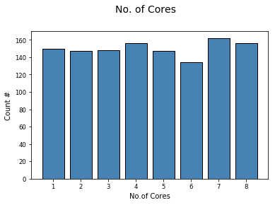

```python
# Bar Plot
fig = plt.figure(figsize = (6, 4))
title = fig.suptitle("No. of Cores", fontsize = 14)
fig.subplots_adjust(top=0.85, wspace=0.3)

ax = fig.add_subplot(1, 1, 1)
ax.set_xlabel("No.of Cores")
ax.set_ylabel("Count #")
w_q = df['n_cores'].value_counts()
w_q = (list(w_q.index), list(w_q.values))
ax.tick_params(axis='both', which='major', labelsize=8.5)
bar = ax.bar(w_q[0], w_q[1], color='steelblue',
        edgecolor='black', linewidth=1)
```

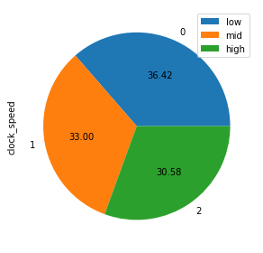

```python
labels = ['low', 'mid', 'high']
df['clock_speed'].value_counts().plot(kind='pie', autopct='%.2f')
plt.tight_layout()
plt.legend(labels)
plt.show()
```

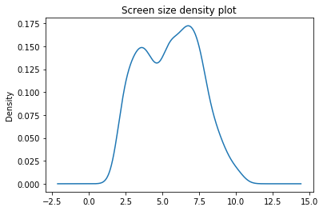

```python
df['screen_size'].plot(kind='density', title="Screen size density plot")
```

## Bivariate visualizations

In this section we try to visualize and analyze two features at a time.

We start with plotting a 2d histogram for `ram` and `price_range`. We can clearly see the density of ram for each price range. Following are the average ram sizes for each price range:

- `low` : 0 - 750 MB
- `mid` : 1250 - 1800 MB
- `high` : ~2500 MB
- `v.high` : 3500 - 4000 MB

We can clearly see the pattern, as price range increases, average ram size also increases.

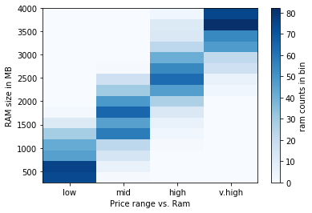

```python
labels = ['low', 'mid', 'high', 'v.high']
h, x, y, i = plt.hist2d(df['price_range'], df['ram'], bins=(4, 16), cmap='Blues')
bin_w = (max(x) - min(x)) / (len(x) - 1)
plt.xticks(np.arange(min(range(0,4))+bin_w/2, max(range(0, 4)), bin_w), labels)
plt.xlabel("Price range vs. Ram")
plt.ylabel("RAM size in MB")
cb = plt.colorbar(i)
cb.set_label('ram counts in bin')
plt.show()
```

Now we plot a bar graph between `dual_sim` and `talk_time` features. Even though there is no clear pattern visible, we can see that talk time for non dual sim phones falls around the higher end and vice versa. From this, we can assume that dual sim phones have less talk time on average as compared to non dual sim phones.

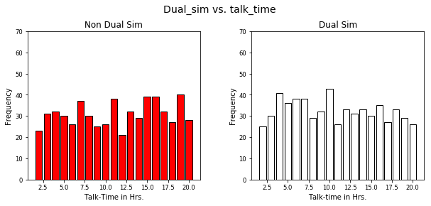

```python
# Using subplots or facets along with Bar Plots
fig = plt.figure(figsize = (10, 4))
title = fig.suptitle("Dual_sim vs. talk_time", fontsize=14)
fig.subplots_adjust(top=0.85, wspace=0.3)

# Non Dual Sim
ax1 = fig.add_subplot(1,2, 1)
ax1.set_title("Non Dual Sim")
ax1.set_xlabel("Talk-Time in Hrs.")
ax1.set_ylabel("Frequency")
rw_q = df[df['dual_sim'] == 0]['talk_time'].value_counts()
rw_q = (list(rw_q.index), list(rw_q.values))
ax1.set_ylim([0,70])
ax1.tick_params(axis='both', which='major', labelsize=8.5)
bar1 = ax1.bar(rw_q[0], rw_q[1], color='red',
               edgecolor='black', linewidth=1)

# Dual Sim
ax2 = fig.add_subplot(1,2, 2)
ax2.set_title("Dual Sim")
ax2.set_xlabel("Talk-time in Hrs.")
ax2.set_ylabel("Frequency")
ww_q = df[df['dual_sim'] == 1]['talk_time'].value_counts()
ww_q = (list(ww_q.index), list(ww_q.values))
ax2.set_ylim([0, 70])
ax2.tick_params(axis='both', which='major', labelsize=8.5)
bar2 = ax2.bar(ww_q[0], ww_q[1], color='white',
               edgecolor='black', linewidth=1)
```

Lastly, we plot a boxplot for `battery_power` vs `price_range`. Here we can see that as the price range increases, battery capacity also tends to increase. But, this is not true for `mid` and `high` range phones. High range phones have very little battery capacity increase as compared to `mid` range phones.

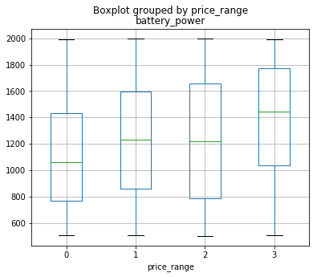

```python
df.boxplot(column='battery_power', by='price_range', figsize=(6,5))
```

## Multivariate visualizations

In this section we try to visualize and analyze three or more features at a time.

To start with, we plot 5 different features with each other in a pair plot, to find any dependence/pattern between features. Following observations can be concluded from the pair plot:

- `ram` feature shows distinct seperation along target feature, meaning the average ram differs most between price range.
- `low` and `v.high` prices phones tend to have lower or higher internal memory respectively. But `mid` and `high` priced phones can have a lot of options avaiable for internal memory sizes.
- all phones tend to have bigger `screen_size`, except `high` priced phones. This may mean that there are people who tend to purchase high priced phones but are looking for smaller screen sizes.
- Only `v.high` priced phones can offer higher battery capacity in general.

[figure not shown]

```python
# Scaling attribute values to avoid few outiers
cols = ['ram', 'int_memory', 'screen_size', 'battery_power','price_range']
pp = sns.pairplot(df[cols], hue='price_range', size=1.8, aspect=1.8,
                  palette={0: "#FF9999", 1: "#FFE888", 2:"#2A9D8F", 3:"#E63946"},
                  plot_kws=dict(edgecolor="black", linewidth=0.5))
fig = pp.fig
fig.subplots_adjust(top=0.93, wspace=0.3)
t = fig.suptitle('Wine Attributes Pairwise Plots', fontsize=14)
```

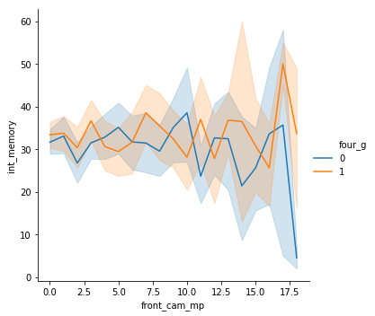

```python
sns.relplot(y="int_memory", x="front_cam_mp", hue='four_g', kind="line", data=df)
```

[figure not shown]

```python
from mpl_toolkits.mplot3d import Axes3D
import matplotlib.pyplot as plt



fig = plt.figure(figsize=(8,6))
ax = fig.add_subplot(111, projection='3d')

ax.scatter(df['battery_power'], df['back_cam_mp'], df['screen_size'], c='orange')

ax.set_xlabel('Battery Power')
ax.set_ylabel('Back_Camera_Px')
ax.set_zlabel('Screen_Size')

plt.show()
```

# Methodology

We are using classification task for this machine learning project. The 4 algorithms used to predit the models are:

1. K-Nearest Neigbors (commonly known as KNN)
2. Decision Tree
3. Random Forest
4. Support Vector Machine (also known as SVM)

Firstly,we have applied cross fold validation on the entire feature present in the dataset after pre-processing & found CV score as **'0.38'**. As the score seemed to be lower,we then decided to go for feature selection to see if any improvement in the accuracy. We applied `f-score` & `random forest importance` methods for feature selection and compared the accuracy of both. Finally we ended up with f-score as best features estimator and used it for further analysis.

We then applied the above mentioned algorithms on the best features given by f-score method and estimated the accuracy of all models. Also for each algorithm, we tuned the parameters and visualised to get the best accuracy score for corresponding model.

Lastly we evaluated the algorithms using the performance metrics and performance comparison using paired t-test

# Feature selection

Feature selection is the process where you automatically select features which contribute most to your prediction variable. Sometimes having many features can decrease the accuracy of model.

1. Performance with full sets of features: We first accessed the performance using all the features of our data. We used `Stratified-K-fold` methods with `splits = 5` and `repetitions = 3` with scoring metric set to accuracy & lastly computed the result using `cross_val_score()`.

```python
from sklearn.neighbors import KNeighborsClassifier
from sklearn.model_selection import cross_val_score,RepeatedStratifiedKFold

Data= df.drop(columns=['price_range'])
target = df[TARGET]
Data = preprocessing.MinMaxScaler().fit_transform(Data)

clf = KNeighborsClassifier(n_neighbors=1)
cv_method = RepeatedStratifiedKFold(n_splits=5, n_repeats=3, random_state=786)
scoring_metric = 'accuracy'
cv_results_full = cross_val_score(estimator=clf, X=Data, y=target, cv=cv_method,scoring=scoring_metric)

cv_results_full.mean().round(2)
```

```
0.38
```

With full set of features & `1` neigbor classifier, we achieved the accuracy score of **38%**.

1. Feature selection using f-score:  
   F-score method selects the features based on relationship between descriptive feature and target feature using F-distribution. We now set number of features to `8`. The `fs_indices_fscore` returns us top 8 features sorted highest to lowest.

```python
Data = df.drop(columns=['price_range'])
target = df[TARGET]
Data = preprocessing.MinMaxScaler().fit_transform(Data)
```

```python
from sklearn import feature_selection as fs
num_features = 8
fs_fit_fscore = fs.SelectKBest(fs.f_classif, k=num_features)
fs_fit_fscore.fit_transform(Data, target)
fs_indices_fscore = np.argsort(np.nan_to_num(fs_fit_fscore.scores_))[::-1][0:num_features]
fs_indices_fscore
```

```
array([ 9,  0,  6,  2, 14,  7, 10,  4])
```

```python
best_features_fscore = df.columns[fs_indices_fscore].values
best_features_fscore
```

```
array(['ram', 'battery_power', 'int_memory', 'clock_speed', 'screen_size',
       'n_cores', 'talk_time', 'front_cam_mp'], dtype=object)
```

- We got `ram, battery_power, int_memory, clock_speed, screen_size, n_cores, talk_time` and `front_cam_mp` as best features based on F-score.

```python
feature_importances_fscore = fs_fit_fscore.scores_[fs_indices_fscore]
feature_importances_fscore
```

```
array([2.16625306e+03, 2.01508823e+01, 3.42542997e+00, 3.07379301e+00,
       2.83311374e+00, 2.32208238e+00, 1.30146226e+00, 1.04149688e+00])
```

```python
import altair as alt

def plot_imp(best_features, scores, method_name, color):

    df = pd.DataFrame({'features': best_features,
                       'importances': scores})

    chart = alt.Chart(df,
                      width=500,
                      title=method_name + ' Feature Importances'
                     ).mark_bar(opacity=0.75,
                                color=color).encode(
        alt.X('features', title='Feature', sort=None, axis=alt.AxisConfig(labelAngle=45)),
        alt.Y('importances', title='Importance')
    )

    return chart
```

```python
plot_imp(best_features_fscore, feature_importances_fscore, 'F-Score', 'red')
```

[output not shown]

*Accessing the performance of the selected features using cross validation.*

```python
cv_results_fscore = cross_val_score(estimator=clf,
                             X=Data[:, fs_indices_fscore],
                             y=target,
                             cv=cv_method,
                             scoring=scoring_metric)
cv_results_fscore.mean().round(3)
```

```
0.605
```

1. Feature selection using Random Forest Importance  
   Random Forest importance (RFI) is widely used feature selector because of the accuracy, robustness and  
   ease of use it gives. It tells us about how much accuracy is decreased when a variable is excluded  
   and decrease in gini impurity when a variable is chosen to split node.

```python
Data= df.drop(columns=['price_range'])
target=df[TARGET]
Data=preprocessing.MinMaxScaler().fit_transform(Data)
```

```python
Data
```

```
array([[0.72660428, 1.        , 0.        , ..., 1.        , 1.        ,
        0.77683957],
       [0.70320856, 0.        , 1.        , ..., 0.        , 0.        ,
        0.34499397],
       [0.76938503, 0.        , 0.        , ..., 1.        , 1.        ,
        0.67913148],
       ...,
       [0.40641711, 0.        , 0.5       , ..., 0.        , 1.        ,
        0.55367913],
       [0.43582888, 0.        , 0.5       , ..., 0.        , 1.        ,
        0.03498191],
       [0.09291444, 1.        , 0.5       , ..., 1.        , 1.        ,
        0.16646562]])
```

```python
from sklearn.ensemble import RandomForestClassifier

model_rfi = RandomForestClassifier(n_estimators=100)
model_rfi.fit(Data, target)
fs_indices_rfi = np.argsort(model_rfi.feature_importances_)[::-1][0:num_features]
```

```python
best_features_rfi = df.columns[fs_indices_rfi].values
best_features_rfi
```

```
array(['ram', 'battery_power', 'screen_size', 'int_memory', 'back_cam_mp',
       'talk_time', 'front_cam_mp', 'n_cores'], dtype=object)
```

- We got `ram`, `battery_power`, `screen_size`,`int_memory`, `talk_time`, `front_cam_mp`, `back_cam_mp` and `n_cores`,as best features based on random forest importance.

```python
feature_importances_rfi = model_rfi.feature_importances_[fs_indices_rfi]
feature_importances_rfi
```

```
array([0.47525871, 0.10213975, 0.07127421, 0.06523768, 0.05342514,
       0.05248444, 0.04568845, 0.04036804])
```

```python
plot_imp(best_features_rfi, feature_importances_rfi, 'Random Forest', 'green')
```

[output not shown]

*Accessing the performance of the selected features using cross validation.*

```python
cv_results_rfi = cross_val_score(estimator=clf,
                             X=Data[:, fs_indices_rfi],
                             y=target,
                             cv=cv_method,
                             scoring=scoring_metric)
cv_results_rfi.mean().round(3)
```

```
0.588
```

Finding the overall performance: We found that F-score feature selector gives us good accuracy score as compared to random forest importance.

Hence we choose `best_feature_f-score` for further fitting the model.

```python
print('Full Set of Features:', cv_results_full.mean().round(3))
print('F-Score:', cv_results_fscore.mean().round(3))
print('RFI:', cv_results_rfi.mean().round(3))
```

```
Full Set of Features: 0.383
F-Score: 0.605
RFI: 0.588
```

### Splitting the data into training and test set

We have selected the sample(1200) of our entire data i.e(2000 rows) for model fitting and evaluation. We have split the data into `70 :30` ratio i.e 70% of our data to build a model and 30% data to test it to ensure that we measure the accuracy based on unseen data.

```python
Data = df[best_features_fscore].copy()
target = df[TARGET]
Data = preprocessing.MinMaxScaler().fit_transform(Data)
```

```python
from sklearn.model_selection import train_test_split

D_train, D_test, t_train, t_test = train_test_split(Data, target, test_size=0.3, random_state=786)
```

# Model fitting

## 1.K-Nearest Neighbor (KNN)

We fit a `KNeighborClassifier` with default parameter values as `n_neigbors = 5` and `P=2`. n_neigbors value is the number of neigbors to be used and `P=2` is the Euclidean distance metric. The score function returns the accuracy of classifier on the test data. Accuracy is ratio of total correctly predicted observations upon total number of observations. Computed accuracy found was 59.44%

```python
from sklearn.neighbors import KNeighborsClassifier
knn_classifier = KNeighborsClassifier(n_neighbors=5, p=2)
knn_classifier.fit(D_train, t_train)
knn_classifier.score(D_test, t_test)
```

```
0.5944444444444444
```

## Hyperparameter tuning using Grid Search

Grid-search is used to find the optimal hyperparameters of a model which results in the most *accurate* predictions.

Below we have defined a function for `grid search` to which we pass the classifier (KNN, DT, RF, and SVM) and training data.

- We have defined different parameters for each algorithm in the `grid_params` method.
- The function returns us best model parameters and model score based on the parameters given.
- In addition we include repeated stratified cv method.
- Also we tell sklean library which metric to optimize i.e. accuracy in our case.

```python
from sklearn.model_selection import GridSearchCV
from sklearn.tree import DecisionTreeClassifier
from sklearn.ensemble import RandomForestClassifier
from sklearn.svm import SVC

def grid_search(D_train, t_train, clf):

    if isinstance(clf, KNeighborsClassifier):
        grid_params = {
        'n_neighbors':[3, 5, 7, 9, 11, 13, 15],
        'p':[1, 2, 3]
        }
    elif isinstance(clf, DecisionTreeClassifier):
        grid_params = {
        'criterion':['gini','entropy'],
        'min_samples_split':[2, 3, 4],
        'max_depth':[1, 2, 3, 4, 5, 6, 7, 8]
        }
    elif isinstance(clf, RandomForestClassifier):
        grid_params = {
        'n_estimators':[110, 130, 150, 200],
        'criterion':['gini','entropy'],
        'min_samples_split':[2, 3, 4],
        'max_depth':[3, 4, 5]

        }
    elif isinstance(clf, SVC):
       grid_params = {
            'C':[1, 10, 50, 100],
            'gamma':[1, 0.1, 0.05, 0.001],
            'kernel':['rbf', 'poly', 'sigmoid']
        }
    else :
        raise ValueError("unkown classifier")

    gs = GridSearchCV(
        estimator = clf,
        param_grid = grid_params,
        verbose = 3,
        cv = cv_method,
        n_jobs = -1,
        refit = True
    )

    gs_results = gs.fit(D_train, t_train)
    p = gs_results.best_params_
    model = gs_results.best_estimator_
    return model, p, gs_results
```

- With `n_neigbors:[3, 5, 7, 9, 11, 13, 15]` and `P: [1, 2, 3]` the grid search function finds out the best parameter values and calculates the model score.

```python
knn_model, knn_best_estimate, knn_result = grid_search(D_train, t_train, knn_classifier)
```

```
Fitting 15 folds for each of 21 candidates, totalling 315 fits
```

```
[Parallel(n_jobs=-1)]: Using backend LokyBackend with 2 concurrent workers.
[Parallel(n_jobs=-1)]: Done  92 tasks      | elapsed:    5.9s
[Parallel(n_jobs=-1)]: Done 315 out of 315 | elapsed:   20.9s finished
```

```python
knn_best_estimate
```

```
{'n_neighbors': 15, 'p': 1}
```

```python
knn_model.score(D_test, t_test)
```

```
0.6888888888888889
```

- KNN classifier with `n_neighbor = 15` and `p = 1` predicted the model mean score of 68.8%

```python
results_KNN = pd.DataFrame(knn_result.cv_results_['params'])
results_KNN['test_score'] = knn_result.cv_results_['mean_test_score']
results_KNN.head()
```

|  | n_neighbors | p | test_score |
| --- | --- | --- | --- |
| 0 | 3 | 1 | 0.585714 |
| 1 | 3 | 2 | 0.568651 |
| 2 | 3 | 3 | 0.552381 |
| 3 | 5 | 1 | 0.638095 |
| 4 | 5 | 2 | 0.600000 |

```python
results_KNN['metric'] = results_KNN['p'].replace([1, 2, 3], ["Manhattan", "Euclidean", "Minkowski"])
results_KNN.head()
```

|  | n_neighbors | p | test_score | metric |
| --- | --- | --- | --- | --- |
| 0 | 3 | 1 | 0.585714 | Manhattan |
| 1 | 3 | 2 | 0.568651 | Euclidean |
| 2 | 3 | 3 | 0.552381 | Minkowski |
| 3 | 5 | 1 | 0.638095 | Manhattan |
| 4 | 5 | 2 | 0.600000 | Euclidean |

### Plotting the KNN Performance comparison.

```python
import altair as alt

alt.Chart(results_KNN,
          title='KNN Performance Comparison'
         ).mark_line(point=True).encode(
    alt.X('n_neighbors', title='Number of Neighbors'),
    alt.Y('test_score', title='Mean CV Score', scale=alt.Scale(zero=False)),
    color='metric'
)
```

[output not shown]

#### Advantages of KNN Classifier:

- The algorithm is simple and easy to implement.
- The algorithm is versatile and can be used for classification, regression and search.

#### Disadvantages:

- The algorithm gets slower as number of independent variables increases where predictions needs to be made  
  rapidly.

#### Limitations:

- Need to have high computing resources to speedly handle the data.

## 2.Decision Tree Clasification

Decision trees are non-parametric supervised learning methods used for classification. The main aim of this is to define a model that gives value of target feature by learning decision rule inferred from data features.  
Fitting the decision tree classifier with default values and `random state = 786` which was selected at the very beginning.  
The score function returns the accuracy of classifier on the test data. Accuracy is ratio of total correctly  
predicted observations upon total number of observations.The accuracy measured was 76.38%.

```python
dt_classifier = DecisionTreeClassifier(random_state=786)
dt_classifier.fit(D_train, t_train)
dt_classifier.score(D_test, t_test)
```

```
0.7638888888888888
```

- Out of Criterion = `gini, entropy`, `min_sample_split = [2, 3, 4]` & `max_depth = [1, 2, 3, 4, 5, 6, 7, 8]` the grid search function finds out the best parameter values and calculates the model score.

```python
dt_model, dt_best_estimate, dt_result = grid_search(D_train, t_train, dt_classifier)
```

```
Fitting 15 folds for each of 48 candidates, totalling 720 fits
```

```
[Parallel(n_jobs=-1)]: Using backend LokyBackend with 2 concurrent workers.
[Parallel(n_jobs=-1)]: Done 720 out of 720 | elapsed:    2.3s finished
```

```python
dt_best_estimate
```

```
{'criterion': 'gini', 'max_depth': 4, 'min_samples_split': 2}
```

```python
dt_model.score(D_test, t_test)
```

```
0.7666666666666667
```

*With Criterion `gini` , `max_depth = 4` and `min_sample_splits` of 2 the model predicts the accuracy 76.6%*

```python
results_DT = pd.DataFrame(dt_result.cv_results_['params'])
results_DT['test_score'] = dt_result.cv_results_['mean_test_score']
results_DT.head()
```

|  | criterion | max_depth | min_samples_split | test_score |
| --- | --- | --- | --- | --- |
| 0 | gini | 1 | 2 | 0.483730 |
| 1 | gini | 1 | 3 | 0.483730 |
| 2 | gini | 1 | 4 | 0.483730 |
| 3 | gini | 2 | 2 | 0.779365 |
| 4 | gini | 2 | 3 | 0.779365 |

### Plotting the DT Performance Comparison

```python
alt.Chart(results_DT,
          title='DT Performance Comparison'
         ).mark_line(point=True).encode(
    alt.X('max_depth', title='Maximum Depth'),
    alt.Y('test_score', title='Mean CV Score', aggregate='average', scale=alt.Scale(zero=False)),
    color='criterion'
)
```

[output not shown]

#### Advantages of Decision tree classifier

- Inexpensive to construct.
- Easy to interpret for small size trees.
- Fast at classifying unknown records.

#### Disadvantages

- Decision tree models are often biased towards splits on features.
- Large trees can be difficult to interpret.
- Small change in training data can account for large change to decision logic.

## 3.Random Forest classifier

A random forest is a Meta estimator that fits number of decision tree classifier on various sub-samples and uses mean to advance the accuracy and avoid over-fitting.  
Fitting the random forest classifier with default estimator `n = 100` i.e. number of trees in the forest,  
criterion `gini` and `max_depth` 2.

The score function returns the accuracy of classifier on the test data. Accuracy is ratio of total correctly predicted observations upon total number of observations. The accuracy measured was *73.6%*.

```python
rf_classifier = RandomForestClassifier(random_state=786,n_estimators=100,max_depth=2,criterion='gini')
rf_classifier.fit(D_train, t_train)
rf_classifier.score(D_test, t_test)
```

```
0.7361111111111112
```

- Out of the given parameters given to grid search function `criterion = [‘gini’, ‘entropy’]`, `n_estimators = [110, 130, 150, 200]`, `max_depth = [3, 4, 5]` and `min_sample_split = [2, 3, 4]` it calculates & returns best parameters with model score.

```python
rf_model, rf_best_estimate, rf_result = grid_search(D_train, t_train, rf_classifier)
```

```
Fitting 15 folds for each of 72 candidates, totalling 1080 fits
```

```
[Parallel(n_jobs=-1)]: Using backend LokyBackend with 2 concurrent workers.
[Parallel(n_jobs=-1)]: Done  52 tasks      | elapsed:    5.1s
[Parallel(n_jobs=-1)]: Done 244 tasks      | elapsed:   26.0s
[Parallel(n_jobs=-1)]: Done 564 tasks      | elapsed:  1.1min
[Parallel(n_jobs=-1)]: Done 1012 tasks      | elapsed:  2.1min
[Parallel(n_jobs=-1)]: Done 1080 out of 1080 | elapsed:  2.3min finished
```

```python
rf_best_estimate
```

```
{'criterion': 'gini',
 'max_depth': 5,
 'min_samples_split': 3,
 'n_estimators': 200}
```

```python
rf_model.score(D_test, t_test)
```

```
0.7777777777777778
```

```python
results_RF = pd.DataFrame(rf_result.cv_results_['params'])
results_RF['test_score'] = rf_result.cv_results_['mean_test_score']
results_RF.head()
```

|  | criterion | max_depth | min_samples_split | n_estimators | test_score |
| --- | --- | --- | --- | --- | --- |
| 0 | gini | 3 | 2 | 110 | 0.784921 |
| 1 | gini | 3 | 2 | 130 | 0.783730 |
| 2 | gini | 3 | 2 | 150 | 0.784921 |
| 3 | gini | 3 | 2 | 200 | 0.779365 |
| 4 | gini | 3 | 3 | 110 | 0.786111 |

### Plotting the RF Performance Comparison

```python
alt.Chart(results_RF,
          title='RF Performance Comparison'
         ).mark_line(point=True).encode(
    alt.X('max_depth', title='Maximum Depth'),
    alt.Y('test_score', title='Mean CV Score', aggregate='average', scale=alt.Scale(zero=False)),
    color='criterion')
```

[output not shown]

#### Advantages of Random forest classifier

- No need of any feature selection
- Easier to make parallel models
- If larger parts of features are lost , accuracy can still be maintained.

#### Disadvantages

- Fits for some noisy data
- Time complexity- much harder and time consuming to construct.

#### Limitations

- Heavy computation resources.

## 4.Support Vector Machine classifier

SVM is linear model for classification problem. The idea of SVM is simple. The algorithm creates  
a line or hyperplane which separates the data into classes.  
We fit the model with default kernel as rbf and regularisation value=1.0 parameters .  
The score function returns the accuracy of classifier on the test data. Accuracy is ratio of total  
correctly predicted observations upon total number of observations. The accuracy measured was 78.6%.

```python
svm_classifier = SVC()
svm_classifier.fit(D_train, t_train)
svm_classifier.score(D_test, t_test)
```

```
0.7861111111111111
```

- The parameters passed to grid search function were gamma `values=[0.1, 0.05, 0.001, 1]` as the value  
  must be between 0.1 to 1. `Kernels=[‘rbf’, ‘poly’, ‘sigmoid’]` with `C=[1, 10, 50, 100]`.

```python
svm_model, svm_best_estimate, svm_result = grid_search(D_train, t_train, svm_classifier)
```

```
Fitting 15 folds for each of 48 candidates, totalling 720 fits
```

```
[Parallel(n_jobs=-1)]: Using backend LokyBackend with 2 concurrent workers.
[Parallel(n_jobs=-1)]: Done 100 tasks      | elapsed:    2.6s
[Parallel(n_jobs=-1)]: Done 484 tasks      | elapsed:   13.5s
[Parallel(n_jobs=-1)]: Done 720 out of 720 | elapsed:   20.7s finished
```

```python
svm_best_estimate
```

```
{'C': 50, 'gamma': 0.05, 'kernel': 'sigmoid'}
```

```python
svm_model.score(D_train, t_train)
```

```
0.8345238095238096
```

```python
results_SVM = pd.DataFrame(svm_result.cv_results_['params'])
results_SVM['test_score'] = svm_result.cv_results_['mean_test_score']
results_SVM.head()
```

|  | C | gamma | kernel | test_score |
| --- | --- | --- | --- | --- |
| 0 | 1 | 1.0 | rbf | 0.795238 |
| 1 | 1 | 1.0 | poly | 0.784524 |
| 2 | 1 | 1.0 | sigmoid | 0.172619 |
| 3 | 1 | 0.1 | rbf | 0.790873 |
| 4 | 1 | 0.1 | poly | 0.286905 |

### Plotting the SVM Performance Comparison

```python
alt.Chart(results_SVM,
          title='SVM Performance Comparison'
         ).mark_line(point=True).encode(
    alt.X('C', title='Regularisation Parameter'),
    alt.Y('test_score', title='Mean CV Score', aggregate='average', scale=alt.Scale(zero=False)),
    color='kernel'
)
```

[output not shown]

## Performance comparison

After testing the classifier by considering the train data and using it in cross validation way,  
we know perform the paired t-test in order to understand if the difference between performance is statistically  
significant for any 2 classifiers.  
Firstly we calculate the cross_val_score and then compare it with all models as:

- KNN-DT
- KNN-RF
- KNN-SVM
- DT-RF
- DT-SVM
- RF_SVM

From scipy library we import the stats module to run the t-test .

```python
from sklearn.model_selection import cross_val_score, StratifiedKFold

cv_method_ttest = StratifiedKFold(n_splits=10, random_state=786)
cv_results_KNN = cross_val_score(estimator=knn_model, X=Data, y=target, cv=cv_method_ttest, n_jobs=-1, scoring='accuracy')
```

```python
cv_results_KNN.mean()
```

```
0.7000298631849434
```

```python
cv_results_RF = cross_val_score(estimator=rf_model, X=Data, y=target, cv=cv_method_ttest, n_jobs=-1, scoring='accuracy')
cv_results_RF.mean()
```

```
0.7949359909252958
```

```python
cv_results_DT = cross_val_score(estimator=dt_model, X=Data, y=target, cv=cv_method_ttest, n_jobs=-1, scoring='accuracy')
cv_results_DT.mean()
```

```
0.7915683380790333
```

```python
cv_results_SVM = cross_val_score(estimator=svm_model, X=Data, y=target, cv=cv_method_ttest, n_jobs=-1, scoring='accuracy')
cv_results_SVM.mean()
```

```
0.823305264254462
```

```python
from scipy import stats

print(stats.ttest_rel(cv_results_KNN, cv_results_DT))
print(stats.ttest_rel(cv_results_KNN, cv_results_RF))
print(stats.ttest_rel(cv_results_KNN, cv_results_SVM))

print(stats.ttest_rel(cv_results_DT, cv_results_RF))
print(stats.ttest_rel(cv_results_DT, cv_results_SVM))

print(stats.ttest_rel(cv_results_RF, cv_results_SVM))
```

```
Ttest_relResult(statistic=-5.175690628053786, pvalue=0.0005827033357749185)
Ttest_relResult(statistic=-4.179672453115473, pvalue=0.002377244384685168)
Ttest_relResult(statistic=-6.222381065086182, pvalue=0.00015465915456455202)
Ttest_relResult(statistic=-0.3264812706568976, pvalue=0.7515244765497536)
Ttest_relResult(statistic=-3.0075809721373896, pvalue=0.014773665419268186)
Ttest_relResult(statistic=-4.532049993566178, pvalue=0.0014220135977982204)
```

*The Pair KNN-SVM gives statistically significant value of 0.0002 which is less than 0.05.*

# Model evaluation

Model evaluation is one of the important step required to determine the best model, how well the model will perform.  
The target variable for our dataset was multinomial. That is target feature is categorical with 4 different  
level {0, 1, 2, 3}. It refers to different price range ={‘low’, ‘mid’, ‘high’, ‘v high’}.  
Hence we cannot use binary metric such as roc_auc curve to evaluate multinomial classifier.  
Below are the evaluation metrics used to find the accuracy, classification report and average model accuracy  
for each model.

```python
from sklearn import metrics
def print_model_stats(model, D_test, t_test):
    pred = model.predict(D_test)
    print("=========={model_name} Model Statistics=============".format(model_name=model.__class__.__name__))
    print("Accuracy score:", metrics.accuracy_score(t_test, pred))
    print("Confusion Matrix:\n", metrics.confusion_matrix(t_test, pred))
    print("Classification report:\n", metrics.classification_report(t_test, pred))
    print("Average model accuracy:", metrics.balanced_accuracy_score(t_test, pred))
```

```python
print_model_stats(knn_model, D_test, t_test)
```

```
==========KNeighborsClassifier Model Statistics=============
Accuracy score: 0.6888888888888889
Confusion Matrix:
 [[71 12  0  0]
 [18 57 16  0]
 [ 1 29 51  8]
 [ 0  2 26 69]]
Classification report:
               precision    recall  f1-score   support

           0       0.79      0.86      0.82        83
           1       0.57      0.63      0.60        91
           2       0.55      0.57      0.56        89
           3       0.90      0.71      0.79        97

   micro avg       0.69      0.69      0.69       360
   macro avg       0.70      0.69      0.69       360
weighted avg       0.70      0.69      0.69       360

Average model accuracy: 0.6915423067928375
```

```python
print_model_stats(dt_model, D_test, t_test)
```

```
==========DecisionTreeClassifier Model Statistics=============
Accuracy score: 0.7666666666666667
Confusion Matrix:
 [[75  8  0  0]
 [17 53 21  0]
 [ 1  9 64 15]
 [ 0  0 13 84]]
Classification report:
               precision    recall  f1-score   support

           0       0.81      0.90      0.85        83
           1       0.76      0.58      0.66        91
           2       0.65      0.72      0.68        89
           3       0.85      0.87      0.86        97

   micro avg       0.77      0.77      0.77       360
   macro avg       0.77      0.77      0.76       360
weighted avg       0.77      0.77      0.76       360

Average model accuracy: 0.7677781363219282
```

```python
print_model_stats(rf_model, D_test, t_test)
```

```
==========RandomForestClassifier Model Statistics=============
Accuracy score: 0.7777777777777778
Confusion Matrix:
 [[75  8  0  0]
 [10 65 16  0]
 [ 0 19 62  8]
 [ 0  0 19 78]]
Classification report:
               precision    recall  f1-score   support

           0       0.88      0.90      0.89        83
           1       0.71      0.71      0.71        91
           2       0.64      0.70      0.67        89
           3       0.91      0.80      0.85        97

   micro avg       0.78      0.78      0.78       360
   macro avg       0.78      0.78      0.78       360
weighted avg       0.78      0.78      0.78       360

Average model accuracy: 0.779663274235098
```

```python
print_model_stats(svm_model, D_test, t_test)
```

```
==========SVC Model Statistics=============
Accuracy score: 0.8305555555555556
Confusion Matrix:
 [[78  5  0  0]
 [ 6 71 14  0]
 [ 0 15 65  9]
 [ 0  0 12 85]]
Classification report:
               precision    recall  f1-score   support

           0       0.93      0.94      0.93        83
           1       0.78      0.78      0.78        91
           2       0.71      0.73      0.72        89
           3       0.90      0.88      0.89        97

   micro avg       0.83      0.83      0.83       360
   macro avg       0.83      0.83      0.83       360
weighted avg       0.83      0.83      0.83       360

Average model accuracy: 0.8316511387024647
```

*Hence we conclude that SVM gives us the best model accuracy and should be used for this predicting target feature.*

# Summary and Conclusion

After cleaning and visualizing the dataset, we were able to find clear pattern for features like `ram` which was proportional to the `price_range`, whereas some features had a very little information gain like `bluetooth` and `wifi`. We also noticed a pattern in `screen-size` for phones, had 2 distinct sizes which were manufactured the most, which aligned with the popular screen sizes provided by big brands(like Apple's iPhone).

There were also some limitations. The f-score method does not reveal information among the features but still we have used due to greater score than random forest importance.

Also we used few cases for feature selection and parameter tuning .we could have explored more taken more parameters and more feature selection methods. This might had helped us giving a better model.

# References

- Sharma, A. (2018). Mobile Price Classification [online]. Retrieved from https://www.kaggle.com/iabhishekofficial/mobile-price-classification
- Vural, A. (2019). Feature Ranking [online]. Retrieved from http://www.featureranking.com
- Pupale, R. (2018). Support Vector Machines(SVM) — An Overview [online]. Retrieved from https://towardsdatascience.com/https-medium-com-pupalerushikesh-svm-f4b42800e989
- https://www.apple.com/iphone-se/specs/
- https://www.apple.com/iphone-11-pro/specs/